# Statistical Inference - Assigment Project-Part 1

Francisco Mimica Porras

2/16/2021

# Overview

In this project we will investigate the exponential distribution in R and compare it with the Central Limit Theorem. The exponential distribution can be simulated in R with rexp(n, lambda) where lambda is the rate parameter. The mean of exponential distribution is 1/lambda and the standard deviation is also 1/lambda.

For the project, the following instructions were provided:

Set lambda = 0.2 for all of the simulations. Investigate the distribution of averages of 40 exponentials. Do a thousand simulations.

# Simulations

The below code setup the parameters as outline in the course project instructions. This includes the rate (lambda), number of exponentials and the number of simulations we wish to run.

We then create a numeric vector (‘means’) which contains the result of the simulations. In this case, our simulations are getting the mean.

Finally, we plot a histogram of the simulated mean values (‘means’).

## Setting seed for reproducability and sampling values according with the instructions.

```r
set.seed(2021)
lambda <- 0.2   # lambda
n <- 40         # number of exponentials
sims <- 1000    # number of simulations
```

## Simulations

```r
sims_exp <- replicate(sims, rexp(n, lambda))
```

## Calculations: Means of exponential simulations

```r
means_sims_exp <- apply(sims_exp, 2, mean)
```

## Plots

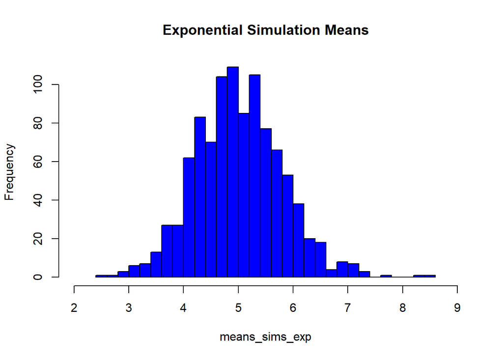

```r
hist(means_sims_exp, breaks=40, xlim = c(2,9), main="Exponential Simulation Means", col = "blue")
```

# Sample Mean versus Theoretical Mean:

## Plot histogram of the sample means.

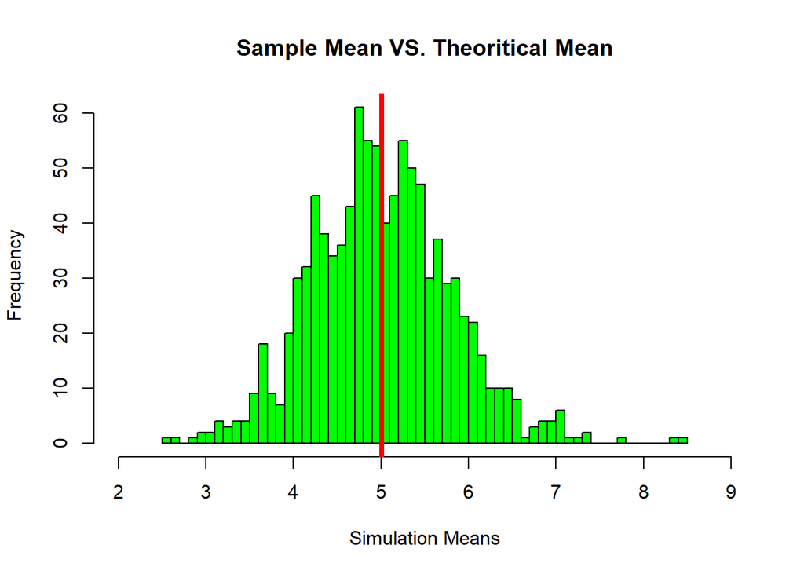

```r
hist(means_sims_exp, col="green", main="Sample Mean VS. Theoritical Mean", xlim = c(2,9),breaks=45, xlab = "Simulation Means")
abline(v=mean(means_sims_exp), lwd="4", col="red")
```

```r
mean(means_sims_exp)
```

```
## [1] 5.008639
```

### The mean of the exponential distribution is 1/lambda. In this case, lambda is 0.2. The theoretical mean should result as 5. The code above shows us that our sample mean is 5. which is the same of our theoretical mean of 5.

# Sample Variance vs Theoretical Variance

## theoretical standard deviation vs. simulation standard deviation

```r
print(paste("Theoretical standard deviation: ", round( (1/lambda)/sqrt(n) ,4)))
```

```
## [1] "Theoretical standard deviation:  0.7906"
```

```r
print(paste("Practical standard deviation: ", round(sd(means_sims_exp) ,4)))
```

```
## [1] "Practical standard deviation:  0.7945"
```

```r
print(paste("Theoretical variance: ", round( ((1/lambda)/sqrt(n))^2 ,4)))
```

```
## [1] "Theoretical variance:  0.625"
```

```r
print(paste("Practical variance: ", round(sd(means_sims_exp)^2 ,4)))
```

```
## [1] "Practical variance:  0.6313"
```

### The formulas and codes show us that the variances are very close.

# Distribution

## General Plot with ditribution curve

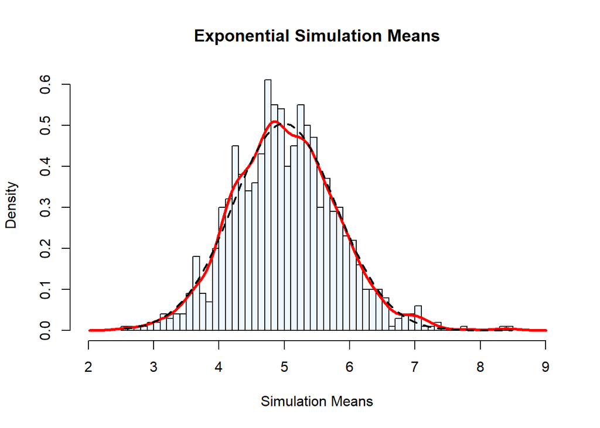

```r
hist(means_sims_exp, prob=TRUE, col="aliceblue", main="Exponential Simulation Means", breaks=45, xlim=c(2,9), xlab = "Simulation Means")
lines(density(means_sims_exp), lwd=3, col="red")

# Normal Distribution
x <- seq(min(means_sims_exp), max(means_sims_exp), length=2*n)
y <- dnorm(x, mean=1/lambda, sd=sqrt(((1/lambda)/sqrt(n))^2))
lines(x, y, pch=22, col="black", lwd=2, lty = 2)
```

### The distribution of means of our sampled exponential distributions appear to follow a normal distribution, due to the Central Limit Theorem.